# Praca domowa nr 3

Paweł Pollak

20 października 2017

# Źródło

Wykres, który nie do końca oddaje “historię”, którą zawierają dane - konkretniej ją przejaskrawia - znajduje się w artykule na stronie money.pl. Pojawił się kilka dni temu (17.10.17). ([link](https://www.money.pl/gospodarka/wiadomosci/artykul/wynagrodzenia-srednia-placa-zatrudnienie-dane,194,0,2377922.html))

# Wykres

Przedstawiony w artykule wykres:

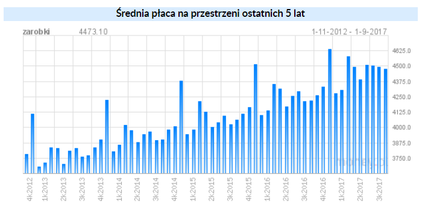

Być może nie było to intencją autora, ponieważ gdyby chciał jeszcze bardziej zaznaczyć spadek, to mógł przedstawić dane jedynie od 2016 roku i znów podwyższyć minimalną wartość osi Y. Z drugiej strony, fakt, że od 2012 średnia płaca rosła (z krótkimi spadkami), a teraz od paru miesięcy jedynie spada wywoła zaniepokojenie również u osób, które dokładniej analizują wykres.

Ten błąd (albo celowe działanie) nie jest niczym nowym. Jednak warto zauważyć, że jest on cały czas obecny, nawet na tego typu portalach. Zatem takie błędy/sztuczki niestety nie należą jeszcze do akademickich przykładów na zasadzie - “tak kiedyś było, ale społeczeństwo już się nauczyło szybko analizować proste wykresy, więc teraz trzeba czegoś więcej”.

Do wytłumaczenia występowania takich wykresów można również podejść od innej strony. Jeżeli mamy bardzo wysokie wartości do przedstawienia, a różnice pomiędzy słupkami są niewielkie to może wystąpić pokusa obcięcia osi Y, w celu wyraźniejszego zaznaczenia różnic. Jeżeli taka operacja nie zostanie wykonana, to słupki będą miały jednakowe długości i wykres nic ciekawego nie wniesie. Jednak w takie podejście w związku ze zmianą proporcji słupków nie powinno mieć miejsca. Należy wtedy wybrać inny sposób wizualizacji danych (lub te dane przetransformować, np. wizualizować same zmiany)